# Police Militarization Data

Minna Heim

2023-02-13

# Task i

```r
#  first, i want to inspect the data to see which state this data is on, and to get an overview on how to merge the data
data_1 <- read_csv("data.csv", show_col_types = FALSE)
data_2 <- read_csv("data2.csv", show_col_types = FALSE)

# view(data_1)
# view(data_2)
head(data_1)
```

```
## # A tibble: 6 × 6
##    fips  year county_name income   pov mil_equip_received
##   <dbl> <dbl> <chr>        <dbl> <dbl>              <dbl>
## 1  1001  2000 Autauga, AL  42463  10.5                276
## 2  1001  2001 Autauga, AL  42183  10.8                  0
## 3  1001  2002 Autauga, AL  42841  10.3                  0
## 4  1001  2003 Autauga, AL  44241  10.4               1996
## 5  1001  2004 Autauga, AL  45379  11.6                  0
## 6  1001  2005 Autauga, AL  45019  10.4                  0
```

```r
head(data_2)
```

```
## # A tibble: 6 × 3
##   county  year   pop
##    <dbl> <dbl> <dbl>
## 1   1001  2001 44434
## 2   1001  2002 45157
## 3   1001  2003 45762
## 4   1001  2004 46933
## 5   1001  2005 47870
## 6   1001  2006 49105
```

```r
# Before merging, i have to change the column name of "county" in data_2 = "fips", so that i can merge the datasets based on this variable.
data_2 <- data_2 %>% rename(fips = "county")

# Merging:
data <- data_1 %>% full_join(data_2, by = c("year", "fips"))
```

# Task ii

```r
# income
summary(data$income)
```

```
##    Min. 1st Qu.  Median    Mean 3rd Qu.    Max.    NA's
##   15025   33179   38871   40742   45949  125635      21
```

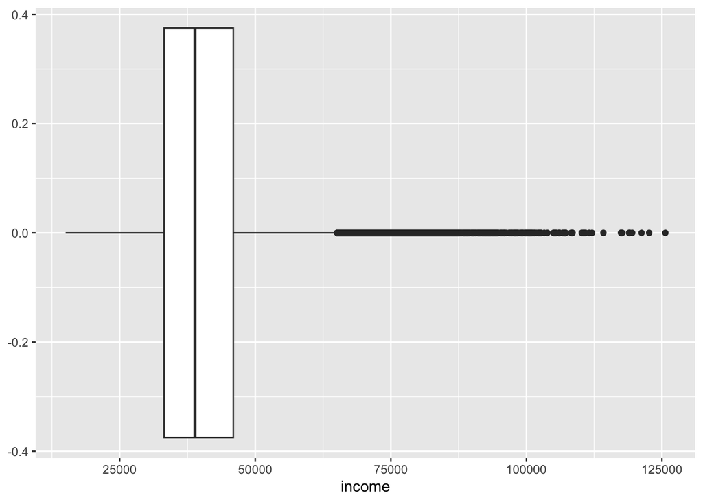

```r
income_plot <- ggplot(data, aes(income)) + geom_boxplot()
income_plot
```

```r
# population
summary(data$pop)
```

```
##    Min. 1st Qu.  Median    Mean 3rd Qu.    Max.    NA's
##      40   13180   33416  215932  139595 9953555    3105
```

When looking at the variable population, we can see the following:

- there are many population observations that have the value “999999”, and when trying to plot the population column with the variable year, the error “3105 rows containing non-finite values (`stat_sum()`)” appears. This leads me to believe, that there are a couple of population obseverations in this dataset that are incorrect / placeholder values.

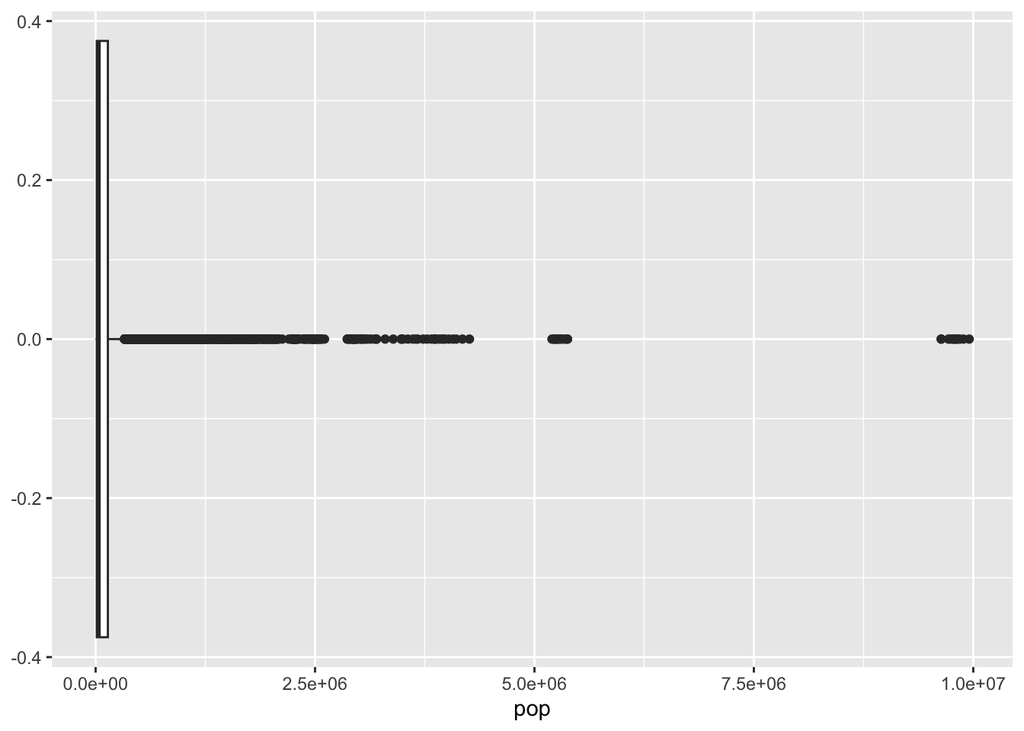

```r
# population
pop_plot <- ggplot(data, aes(pop)) + geom_boxplot()
pop_plot
```

```r
# poverty
summary(data$pov)
```

```
##    Min. 1st Qu.  Median    Mean 3rd Qu.    Max.
##    1.70   10.80   14.30   15.53   18.70  120.00
```

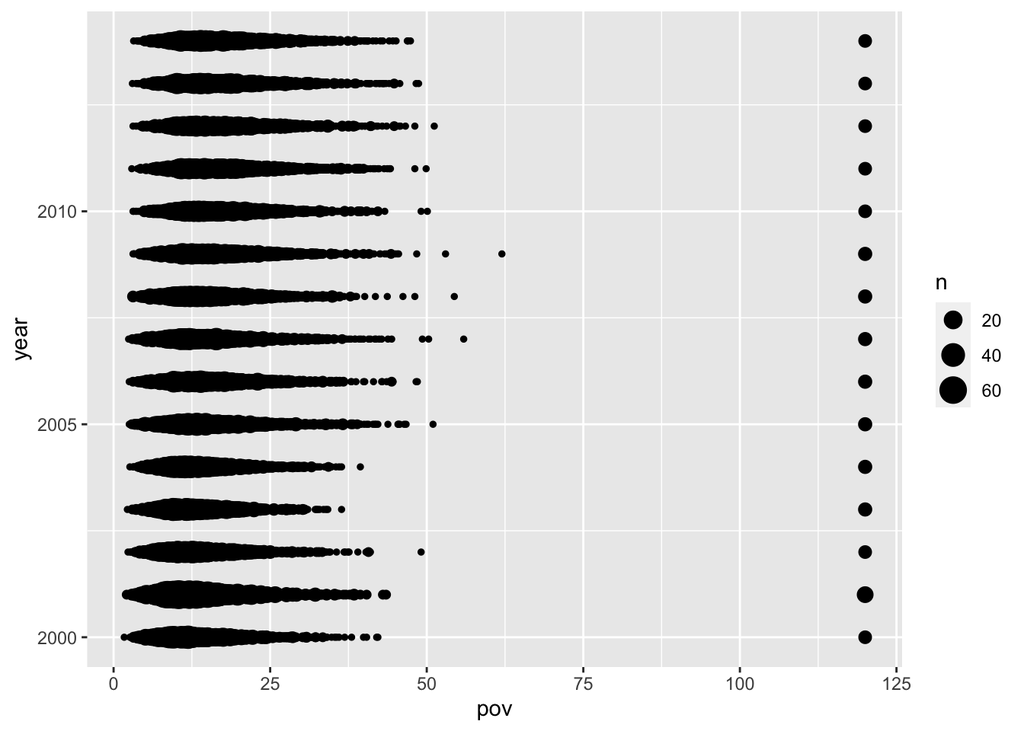

```r
# plotting the poverty rates in year, to see the frequency of certain poverty rates appearing

pov_plot <- ggplot(data, aes(pov, year)) + geom_count()
pov_plot
```

What I can see from the variable poverty (calculated in percent):

- is that the maximum value is 120%. This seems rather implausible. Also,**when looking at the frequency of the appearance of the observation 120, we can see that this appears often, see the plot. Maybe this is another placeholder value.

```r
# military equipment received
summary(data$mil_equip_received)
```

```
##    Min. 1st Qu.  Median    Mean 3rd Qu.    Max.
##       0       0       0   10691       0 5614404
```

```r
# plotting the poverty rates in year, to see the frequency of certain poverty rates appearing
```

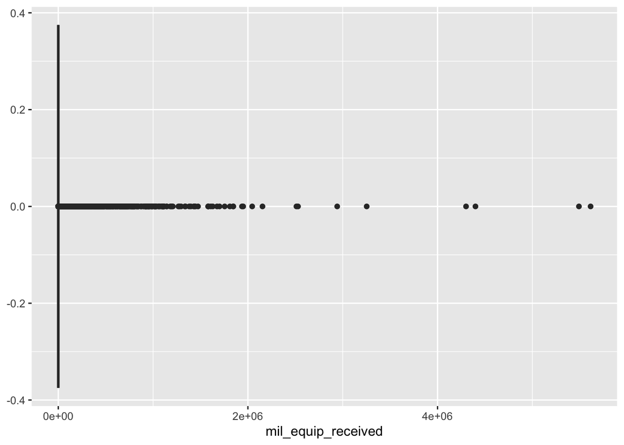

```r
# military equipment received
mil_equip_plot <- ggplot(data, aes(mil_equip_received)) + geom_boxplot()
mil_equip_plot
```

# Task iii

## Task iii (i)

```r
inc_mil_model <- lm(income ~ mil_equip_received, data)
summary(inc_mil_model)
```

```
##
## Call:
## lm(formula = income ~ mil_equip_received, data = data)
##
## Residuals:
##    Min     1Q Median     3Q    Max
## -57136  -7518  -1861   5182  85024
##
## Coefficients:
##                     Estimate Std. Error t value Pr(>|t|)
## (Intercept)        4.061e+04  4.996e+01  812.88   <2e-16 ***
## mil_equip_received 1.225e-02  5.638e-04   21.72   <2e-16 ***
## ---
## Signif. codes:  0 '***' 0.001 '**' 0.01 '*' 0.05 '.' 0.1 ' ' 1
##
## Residual standard error: 11050 on 49683 degrees of freedom
##   (21 observations deleted due to missingness)
## Multiple R-squared:  0.009407,   Adjusted R-squared:  0.009387
## F-statistic: 471.8 on 1 and 49683 DF,  p-value: < 2.2e-16
```

```r
inc_mil_correlation <- cor.test(data$income, data$mil_equip_received,
                    method = "pearson")

inc_mil_correlation
```

```
##
##  Pearson's product-moment correlation
##
## data:  data$income and data$mil_equip_received
## t = 21.721, df = 49683, p-value < 2.2e-16
## alternative hypothesis: true correlation is not equal to 0
## 95 percent confidence interval:
##  0.08827283 0.10569342
## sample estimates:
##        cor
## 0.09699056
```

I calculated the Pearson Correlation again, and it looks as though this result is significant because the p value is < 2.2e-16, which is less than the significance level of 0.05. This correlation test shows that these two variables are only slightly correlated, with a correlation coefficient of 0.09699056. These two variables are positively correlated, which means that they relationship of these two variables moves in the same direction, i.e. when income increases, so does military spending.

## Task iii (ii)

```r
pov_mil_model <- lm(pov ~ mil_equip_received, data)
summary(pov_mil_model)
```

```
##
## Call:
## lm(formula = pov ~ mil_equip_received, data = data)
##
## Residuals:
##     Min      1Q  Median      3Q     Max
## -13.814  -4.711  -1.211   3.189 104.489
##
## Coefficients:
##                     Estimate Std. Error t value Pr(>|t|)
## (Intercept)        1.551e+01  3.635e-02 426.686  < 2e-16 ***
## mil_equip_received 1.516e-06  4.103e-07   3.695  0.00022 ***
## ---
## Signif. codes:  0 '***' 0.001 '**' 0.01 '*' 0.05 '.' 0.1 ' ' 1
##
## Residual standard error: 8.045 on 49704 degrees of freedom
## Multiple R-squared:  0.0002746,  Adjusted R-squared:  0.0002545
## F-statistic: 13.65 on 1 and 49704 DF,  p-value: 0.00022
```

This simple linear regression shows us the following:

The first intercept is county poverty rate (in percent), when the total value of military equipment acquired by local police forces in a given county/year is equal to 0. The second coefficient (beta1) shows us that when the total value of military equipment acquired by local police forces in a given county/year increases by one dollar, that the poverty rate increases by 0.000001516 percent, holding all else constant. Both coefficients are significant on a level of 0.001.

```r
pov_mil_correlation <- cor.test(data$pov, data$mil_equip_received,
                    method = "pearson")

pov_mil_correlation
```

```
##
##  Pearson's product-moment correlation
##
## data:  data$pov and data$mil_equip_received
## t = 3.6951, df = 49704, p-value = 0.00022
## alternative hypothesis: true correlation is not equal to 0
## 95 percent confidence interval:
##  0.007781767 0.025359235
## sample estimates:
##        cor
## 0.01657178
```

Looking at the pearson’s correlation again, we can see the following: There is a slight positive correlation between the poverty rate variables and the military equipment variable. Also, the p value here is 0.00022, which is less than the 0.05 significance level, making this result statistically significant.

Looking at both of the correlation tests: income ~ mil_equip_received and pov ~ mil_equip_received, I would like to point out the following.

- There are slightly positive correlations between both income and military equipment and poverty and military equipment
- Still, there is a stronger correlation between income and military equipment, rather than with military and poverty.

Overall, however, it looks likee more military material tends to go to richer counties.

# Task iv

```r
# I will create the variable "cumulative_equip_received" to be a new dataframe containing only the fips in one column and in the other the sum of the military equipment received.

cumulative_equip_received_1001_1 <- data %>% group_by(fips) %>% summarise(county_total_equip_received = sum(mil_equip_received))
cumulative_equip_received_1001_1
```

```
## # A tibble: 3,107 × 2
##     fips county_total_equip_received
##    <dbl>                       <dbl>
##  1  1001                     101839
##  2  1003                     668753.
##  3  1005                     162488.
##  4  1007                     225300.
##  5  1009                    1393273.
##  6  1011                      41061
##  7  1013                     384460.
##  8  1015                    2902017.
##  9  1017                      64054
## 10  1019                     553028.
## # … with 3,097 more rows
```

# Task v

```r
# I was confused here, unclear whether to take just the military equipment divided by the population, or to take the average military equipment (over all counties) and then divide this by the population.

mil_equip_pp_yearly <- data %>% group_by(year) %>% mutate(avg_mil_equip = mean(mil_equip_received)) %>% mutate(avg_mil_equip_pp = (avg_mil_equip/pop))

head(mil_equip_pp_yearly)
```

```
## # A tibble: 6 × 9
## # Groups:   year [5]
##    fips  year county_name income   pov mil_equip_received   pop avg_mi…¹ avg_m…²
##   <dbl> <dbl> <chr>        <dbl> <dbl>              <dbl> <dbl>    <dbl>   <dbl>
## 1  1001  2000 Autauga, AL  42463  10.5                276    NA     845. NA
## 2  1001  2001 Autauga, AL  42183  10.8                  0 44434    1239.  0.0279
## 3  1001  2001 Autauga, AL  42183  10.8                  0 44434    1239.  0.0279
## 4  1001  2002 Autauga, AL  42841  10.3                  0 45157     690.  0.0153
## 5  1001  2003 Autauga, AL  44241  10.4               1996 45762    1782.  0.0389
## 6  1001  2004 Autauga, AL  45379  11.6                  0 46933    1188.  0.0253
## # … with abbreviated variable names ¹avg_mil_equip, ²avg_mil_equip_pp
```

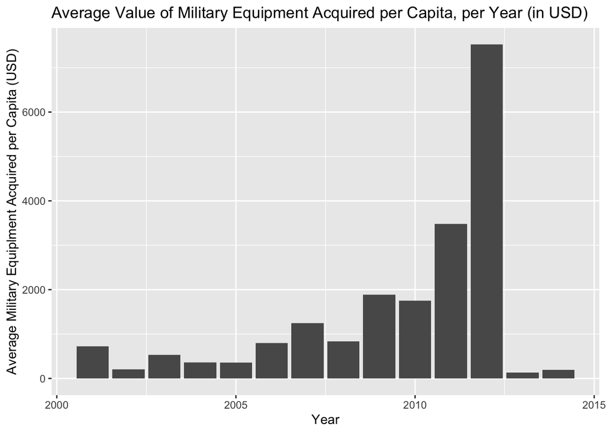

```r
# Plotting the series

# I decided to remove all of the variables that i will not plot, just to make it clearer for me

mil_equip_pp_yearly_df <- mil_equip_pp_yearly %>% select(-fips, -county_name, -income, -pop, -avg_mil_equip, -mil_equip_received, -pov)
# head(mil_equip_pp_yearly_df)

mil_equip_pp_yearly_plot <- ggplot(mil_equip_pp_yearly_df, aes(year, avg_mil_equip_pp)) +
                            geom_col() +
                            labs(title =  "Average Value of Military Equipment Acquired per Capita, per Year (in USD)", x = "Year", y = "Average Military Equiplment Acquired per Capita (USD)")

mil_equip_pp_yearly_plot
```

Interpretation: As we can see from the graph, the highest average value of military equipment acquired by local police forces per capita was the highest in the year 2012.

# Task vi

```r
# filter out rows with no military equipment received (we are only looking at the years where equip was delivered)
filtered_data <- data %>% filter( mil_equip_received > 0)


# group by fips and select minimum year, to see when each county received their first mil equip
filtered_data <- filtered_data %>% group_by(fips) %>% mutate(first_year_rec = min(year, na.rm = TRUE))

#select only the first year received and remove the others.
filtered_data <- filtered_data %>% filter( year == first_year_rec)

# remove all that received in 2000.
filtered_data <- filtered_data %>% filter(first_year_rec > 2000)

# Order by size of military equipment
filtered_data <- filtered_data %>% arrange(desc(mil_equip_received))
head(filtered_data)
```

```
## # A tibble: 6 × 8
## # Groups:   fips [6]
##    fips  year county_name    income   pov mil_equip_received     pop first_yea…¹
##   <dbl> <dbl> <chr>           <dbl> <dbl>              <dbl>   <dbl>       <dbl>
## 1 40119  2014 Payne, OK       41037  23.7           1447501   999999        2014
## 2 35001  2008 Bernalillo, NM  46988  14.3            922704   635444        2008
## 3 29095  2012 Jackson, MO     44634  18.7            783434.  677321        2012
## 4 32003  2011 Clark, NV       48343  16.8            779285. 1966295        2011
## 5 16041  2014 Franklin, ID    50545  10.8            742423   999999        2014
## 6 35049  2014 Santa Fe, NM    52628  14.2            716060   999999        2014
## # … with abbreviated variable name ¹first_year_rec
```

**final verdict:** The county Payne, OK has acquired the largest initial equipment in 2014.

The End.